# Prueba

```python
import pandas as pd
import numpy as np
from datetime import datetime,timedelta
from sklearn.metrics import mean_squared_error
from scipy.optimize import curve_fit
from scipy.optimize import fsolve
from sklearn import linear_model
import matplotlib.pyplot as plt
%matplotlib inline

url = 'C:/Users/china/Downloads/CasosCovidProvincias.csv'
df = pd.read_csv(url)
df=df.loc[df['Provincia'] == 'Manabi']
df=df.iloc[0,:]
df
```

```
Provincia     Manabi
16/3/2020          1
17/3/2020          1
18/3/2020          8
19/3/2020          8
20/3/2020          9
21/3/2020          9
22/3/2020         25
23/3/2020         27
24/3/2020         32
25/3/2020         38
26/3/2020         38
27/3/2020         40
28/3/2020         44
29/3/2020         50
30/3/2020         50
31/3/2020         54
1/4/2020          56
2/4/2020          61
3/4/2020          67
4/4/2020          71
5/4/2020          77
6/4/2020          88
7/4/2020         115
8/4/2020         132
9/4/2020         159
10/4/2020        188
11/4/2020        204
12/4/2020        214
13/4/2020        215
14/4/2020        219
15/4/2020        227
16/4/2020        244
17/4/2020        262
18/4/2020        274
19/4/2020        286
20/4/2020        296
21/04/2020       296
22/04/2020       316
Name: 13, dtype: object
```

**MODELO LINEAL**

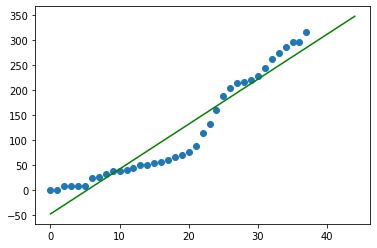

```python
from sklearn.linear_model import LinearRegression
from sklearn.preprocessing import PolynomialFeatures
y=list(df.iloc[:])
y1=y[1:39]
x1 = np.array(range(0,38))
regr = linear_model.LinearRegression()
regr.fit(np.array(x1).reshape(-1, 1) ,y1)
plt.scatter(x1, y1)
x_real = np.array(range(0,45))
plt.plot(x_real, regr.predict(x_real.reshape(-1, 1)), color='green')
plt.show()
```

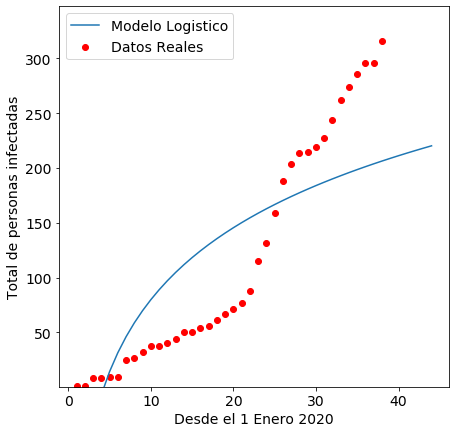

```python
y=list(df.iloc[:])
y1=y[1:39]
x1 = np.array(range(1,39))
def modelo_logistico(x,a,b):
    return a+b*np.log(x)

exp_fit = curve_fit(modelo_logistico,x1,y1) #Extraemos los valores de los paramatros
pred_x = list(range(min(x1),max(x1)+7)) # Predecir 50 dias mas
plt.rcParams['figure.figsize'] = [7, 7]
plt.rc('font', size=14)
# Real data
plt.scatter(x1,y1,label="Datos Reales",color="red")
# Predicted exponential curve
plt.plot(pred_x, [modelo_logistico(i,exp_fit[0][0],exp_fit[0][1]) for i in pred_x], label="Modelo Logistico" )
plt.legend()
plt.xlabel("Desde el 1 Enero 2020")
plt.ylabel("Total de personas infectadas")
plt.ylim((min(y1)*0.4,max(y1)*1.1)) # Definir los limites de Y
plt.show()
```

**MODELO EXPONENCIAL**

```
[0.1218904  1.74926151]
```

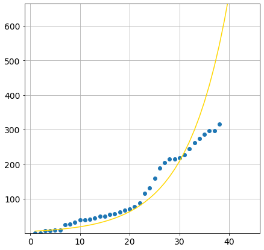

```python
y=list(df.iloc[:])
y1=y[1:39]
x1 = np.array(range(1,39))
pred_x = np.array(list(range(min(x1),max(x1)+7)))
xd = np.log(x1)
yd = np.log(y1)

##Ajuste polinomial
curve_fit = np.polyfit(x1,yd, deg=1)
print(curve_fit)
yx = np.exp(1.74) * np.exp(0.12*pred_x)
plt.plot(x1, y1, "o")
plt.plot(pred_x, yx, color='gold')
plt.ylim((min(y1)*0.9,max(y1)*2.1)) # Definir los limites de Y
plt.grid(True)
```

**MODELO POLINOMIAL**

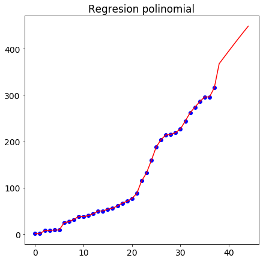

```python
from sklearn.linear_model import LinearRegression
from sklearn.preprocessing import PolynomialFeatures
y=list(df.iloc[:])
y1=y[1:39]
x1 = np.array(range(0,38)).reshape(-1, 1)

lin = LinearRegression()
lin.fit(x1, y1)
poly = PolynomialFeatures(degree = 3)
X_poly = poly.fit_transform(x1)

poly.fit(X_poly, y1)
lin2 = LinearRegression()
lin2.fit(X_poly, y1)
plt.scatter(x1, y1, color = 'blue')
X1 =  np.array(range(40,47)).reshape(-1, 1)
pre = lin2.predict(poly.fit_transform(X1))
for i in pre:
    y1.append(i)
x2=np.array(range(0,45))
plt.plot(x2, y1, color = 'r')
plt.title('Regresion polinomial')
plt.show()
```

**MODELO SIR**

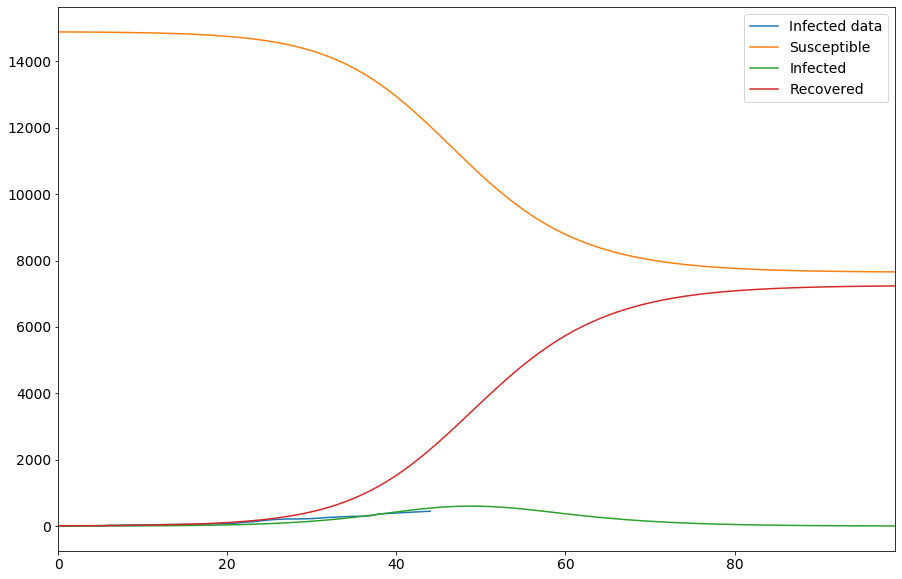

```python
from scipy.integrate import solve_ivp
from scipy.optimize import minimize
from scipy.integrate import odeint

def loss(point, data, s0, i0, r0):
    size = len(data)
    beta, gamma = point
    def SIR(t, y):
        S = y[0]
        I = y[1]
        R = y[2]
        return [-beta*S*I, beta*S*I-gamma*I, gamma*I]
    solution = solve_ivp(SIR, [0, size], [s0,i0,r0], t_eval=np.arange(0, size, 1), vectorized=True)
    return np.sqrt(np.mean((solution.y[1] - data)**2))
i0=2
r0=10
s0=14888
x=np.array(range(0,45))
data= y1
optimal = minimize(loss, [0.001, 0.001], args=(data,s0,i0, r0), method='L-BFGS-B', bounds=[(0.00001,0.4), (0.00001, 0.4)])
beta, gamma = optimal.x
def predict(beta, gamma, data, s0, i0, r0):
    new_index = np.array(range(0,100))
    size = len(new_index)
    def SIR(t, y):
        S = y[0]
        I = y[1]
        R = y[2]
        return [-beta*S*I, beta*S*I-gamma*I, gamma*I]
    extended_actual = np.concatenate((data, [None] * (size - len(data))))
    return new_index, extended_actual, solve_ivp(SIR, [0, size], [s0,i0,r0], t_eval=np.arange(0, size, 1))

new_index, extended_actual,prediction = predict(beta, gamma, data,s0,i0,r0)
df = pd.DataFrame({'Infected data': extended_actual,'Susceptible': prediction.y[0], 'Infected': prediction.y[1], 'Recovered': prediction.y[2]}, index=new_index)
fig, ax = plt.subplots(figsize=(15, 10))
df.plot(ax=ax)
```

```python
print(beta)
print(gamma)
N=18200
R0=(beta/gamma)
RE=R0*N
print(RE)
```

```
3.681405321674777e-05
0.39999333487751204
1.6750673326843935
```

```python
from random import randrange # Obtener un numero randomico
import pygame

#Parametros de inicio
PROBA_MUERTE = 8.5  # Probabilidad de que la gente muera COVID
CONTAGION_RATE = RE # Factor R0 para la simulacion COVID probabilidad
PROBA_INFECT = CONTAGION_RATE * 10
PROBA_VACU = 0 # Probabilidad de que exista una vacuna, COVID = 0
SIMULACION_SPEED = 75 # Tiempo de un dia en milisegundos (Cada 25 es un dia)
nb_rows = 50 #Numero de filas
nb_cols = 50 #Numero de columnas

global display, myfont, states, states_temp #Declaracion de variables globales

#Declaro colores en formato RGB
WHITE = (255, 255, 255)
BLUE = (0, 0, 255)
GREEN = (0, 247, 0)
BLACK = (0, 0, 0)

#Obtiene los vecinos dado un punto x,y
def get_vecinos(x, y):
    incx = randrange(3)
    incy = randrange(3)
    incx = (incx * 1) - 1
    incy = (incy * 1) - 1
    x2 = x + incx
    y2 = y + incy
    #Validar limites
    if x2 < 0:
        x2 = 0
    if x2 >= nb_cols:
        x2 = nb_cols - 1
    if y2 < 0:
        y2 = 0
    if y2 >= nb_rows:
        y2 = nb_rows - 1
    return [x2, y2] # Nuevos contagiados

#Genero las personas que cuentan con inmunidad o vacuna
def vacunar():
    for x in range(nb_cols):
        for y in range(nb_rows):
            if randrange(99) < PROBA_VACU:
                states[x][y] = 1

#Funcion que permite contar el numero de muertosde la matriz states == -1
def contar_muertes():
    contador = 0
    for x in range(nb_cols):
        for y in range(nb_rows):
            if states[x][y] == -1:
                contador +=  1
    return contador

#Definimos datos de inicio
states = [[0] * nb_cols for i1 in range(nb_rows)]
states_temp = states.copy()
states[randrange(50)][randrange(50)] = 10 # Estado inicial de la simulacion Posicion del Infectado
it = 0 # Variable para contar las Iteraciones
total_muerte = 0 # Contabiliza el numero de muertos
vacunar() #Llamar a la funcion vacunar

pygame.init() #Incializo el motor de juegos pygame
pygame.font.init() #Inicializo el tipo de letra
display=pygame.display.set_mode((800,750),0,32) #Tamanio de la ventana
pygame.display.set_caption("Simulacion de Epidemia Covid-19 Ecuador")# Titulo
font=pygame.font.SysFont('Calibri', 40) # Tipo de letra
display.fill(WHITE) # Color de fondo

while True:
    pygame.time.delay(SIMULACION_SPEED) # Sleep o pausa
    it = it + 1
    if it <= 10000 and it >= 2:
        states_temp = states.copy() #Copia de la matriz
        #Recorrera la matriz
        for x in range(nb_cols):
            for y in range(nb_rows):
                state = states[x][y]
                if state == -1:
                    pass
                if state >= 7: # Numero de dias de contagio
                    states_temp[x][y] = state + 1
                if state >= 20:
                    if randrange(99) < PROBA_MUERTE: # Genero un randomico para verificar si fallece o se recupera
                        states_temp[x][y] = -1 # Muere
                    else:
                        states_temp[x][y] = 1 # Cura o recupera
                if state >= 10 and state <= 20: # Rango de infectado
                    if randrange(99) < PROBA_INFECT: # Infecto a las personas cercanas entre  10 y 20
                        neighbour = get_vecinos(x, y) #Obtenemos los vecinos a contagiar
                        x2 = neighbour[0]
                        y2 = neighbour[1]
                        neigh_state = states[x2][y2]
                        if neigh_state == 0: #Verifico que este sano
                            states_temp[x2][y2] = 10 # Contagia
        states = states_temp.copy()
        total_muerte = contar_muertes() # contar el numero de muertos

    pygame.draw.rect(display, WHITE, (250, 30, 260, 50)) # Grafico el fondo
    textsurface = font.render("Total muertes: "+ str(total_muerte), False, (255,160,122)) #El numero de muertos
    display.blit(textsurface, (250, 30)) # Graficar el texto de muertes
    #Graficar el estado del paciente matriz
    for x in range(nb_cols):
        for y in range(nb_rows):
            if states[x][y] == 0:
                color = BLUE # No infectado
            if states[x][y] == 1:
                color = GREEN # Recupero
            if states[x][y] >= 10:
                color = (states[x][y] * 12, 50, 50) # Injectado - Rojo
            if states[x][y] == -1:
                color = BLACK # Muerto
            pygame.draw.circle(display, color, (100 + x * 12 + 5, 100 + y * 12 + 5), 5)
            pygame.draw.rect(display, WHITE, (100 + x * 12 + 3, 100 + y * 12 + 4, 1, 1))
    #Escuachar los eventos del teclado
    for event in pygame.event.get():
        if event.type == pygame.KEYDOWN and event.key == pygame.K_ESCAPE: #Presiona y Escape
            pygame.quit() #Termino simulacion
        if event.type == pygame.KEYDOWN and event.key == pygame.K_SPACE: #Presiona y espacio
            #Reiniciamos valores
            states = [[0] * nb_cols for i1 in range(nb_rows)]
            states_temp = states.copy()
            states[5][5] = 10
            it = 0
            total_muerte = 0
            vacunar() #Llamar a la funcion vacunar

    pygame.display.update()# Mandar actualizar la ventana
```

[output not shown]

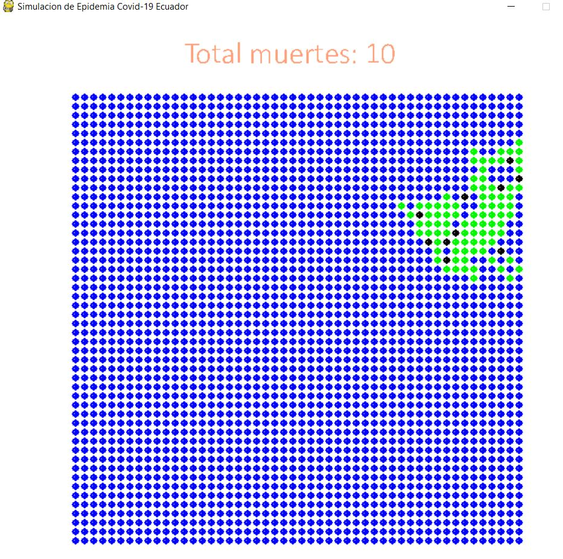

```python
print("Total de muertes")
print(total_muerte)
```

```
Total de muertes
10
```

**ANALISIS**

1.- Cual tiene una mejor prediccion

Dentro de los modelos matemáticos que apreciamos en los apartados anteriores, distinguimos que el modelo de regresión polinomial es el que tiene mejor ajuste de datos, son los que presentan menor desviación estándar, simplifican el tratamiento de datos, permitiendo un análisis más riguroso de los resultados.

2.- Ventajas y desventajas de los modelos

**Modelos de regresión linal:**

Ventajas

- Fácil de entender y explicar
- Es rápido de modelar y es particularmente útil cuando la relación a modelar no es extremadamente compleja y no tiene mucha información.
- Es menos propenso al sobreajuste

Desventajas

- No se puede modelar relaciones complejas.
- No se pueden capturar relaciones no lineales sin transformar la entrada, por lo que tienes que trabajar duro para que se ajuste a funciones no lineales.
- Puede sufrir con valores atípicos.

**Modelo de regresión logístico**

Ventajas

- Es de utilidad para la investigación clí-nica y epidemiológica, modela la probabilidad de un evento en forma de factores de riesgos
- Permiten el análisis de los resultados en términos explicativos y predictivos.
- Es mejor cuando se utilizan atributos relacionados con la de salida

Desventajas

- Imposibilidad de resolver directamente problemas no lineales.
- La dependencia que muestra en las características. Ya que no es una herramienta útil para identificar las características más adecuadas.

**Modelo de regresión exponencial**

Ventajas

- Tiene la virtud de realizar aproximaciones a valores muy alto

Desventajas

- El modelo exponencial puede dejar de ser adecuado por los factores limitantes de crecimiento

**Modelo de regresión polinomial**

Ventajas

- Extiende el modelo lineal al agregar predictores adicionales, obtenidos al elevar cada uno de los predictores originales a una potencia

Desventajas

- A medida que aumentamos la complejidad de la fórmula, el número de características también aumenta, lo que a veces es difícil de manejar.
- La Regresión Polinomial tiene una tendencia a ajustarse drásticamente, incluso es un simple conjunto de datos unidimensional. Si bien podamos tener una tentación de ajustar un polinomio de mayor grado para obtener un error menos, esto puede resultar en un ajuste excesivo, por esa razón siempre se debe trazar las relaciones para ver el ajuste y concentrarnos de que la curva se ajuste a la naturaleza del problema.